# Multi-Class Classification Model for Human Activity Recognition with Smartphone Using R Take 2

David Lowe

October 24, 2018

Template Credit: Adapted from a template made available by Dr. Jason Brownlee of Machine Learning Mastery. [http://machinelearningmastery.com/]

Template Credit: Adapted from a template made available by Dr. Jason Brownlee of Machine Learning Mastery. https://machinelearningmastery.com/

SUMMARY: The purpose of this project is to construct a prediction model using various machine learning algorithms and to document the end-to-end steps using a template. The Human Activities with Smartphone Dataset is a multi-class classification situation where we are trying to predict one of the six possible outcomes.

INTRODUCTION: Researchers collected the datasets from experiments that consist of a group of 30 volunteers with each person performed six activities wearing a smartphone on the waist. With its embedded accelerometer and gyroscope, the research captured measurement for the activities of WALKING, WALKING_UPSTAIRS, WALKING_DOWNSTAIRS, SITTING, STANDING, LAYING. The dataset has been randomly partitioned into two sets, where 70% of the volunteers were selected for generating the training data and 30% the test data.

In iteration Take1, the script focuses on evaluating various machine learning algorithms and identify the algorithm that produces the best accuracy metric. Iteration Take1 established a baseline performance regarding accuracy and processing time. For this iteration, we will examine the feasibility of using dimensionality reduction techniques to reduce the processing time while still maintaining an adequate level of prediction accuracy. The first technique we will explore is to eliminate collinear attributes based on a threshold of 85%.

CONCLUSION: From the previous iteration Take 1, the baseline performance of the ten algorithms achieved an average accuracy of 91.67%. Three algorithms (Linear Discriminant Analysis, Support Vector Machine, and Stochastic Gradient Boosting) achieved the top three accuracy scores after the first round of modeling. After a series of tuning trials, Stochastic Gradient Boosting turned in the top result using the training data. It achieved an average accuracy of 98.84%. Stochastic Gradient Boosting also processed the validation dataset with an accuracy of 95.49%, which was slightly below the accuracy from the training data.

From the model-building activities, the number of attributes went from 561 down to 192 after eliminating 369 variables that are at least 85% collinear. The processing time went from 21 hours 43 minutes in iteration Take1 down to 7 hours and 15 minutes in iteration Take2. That was a reduction in model training and processing time of 66%.

In conclusion, the reduction in the number of attributes used still achieved an acceptable level of accuracy. by reducing the collinearity, the modeling took a much shorter time to process yet still retained decent accuracy. For this dataset, the Stochastic Gradient Boosting algorithm should be considered for further modeling or production use.

Dataset Used: Human Activity Recognition Using Smartphone Data Set

Dataset ML Model: Multi-class classification with numerical attributes

Dataset Reference: https://archive.ics.uci.edu/ml/datasets/Human+Activity+Recognition+Using+Smartphones

One potential source of performance benchmarks: https://www.kaggle.com/uciml/human-activity-recognition-with-smartphones

The project aims to touch on the following areas:

1. Document a predictive modeling problem end-to-end.
2. Explore data cleaning and transformation options
3. Explore non-ensemble and ensemble algorithms for baseline model performance
4. Explore algorithm tuning techniques for improving model performance

Any predictive modeling machine learning project genrally can be broken down into about six major tasks:

1. Prepare Problem
2. Summarize Data
3. Prepare Data
4. Model and Evaluate Algorithms
5. Improve Accuracy or Results
6. Finalize Model and Present Results

## 1. Prepare Problem

### 1.a) Load libraries

```r
startTimeScript <- proc.time()
library(caret)
```

```r
library(corrplot)
library(parallel)

# Create one random seed number for reproducible results
seedNum <- 888
set.seed(seedNum)
```

### 1.b) Load dataset

```r
widthVector <- rep(16, 561)
colNames <- paste0("attr",1:561)
x_train <- read.fwf("X_train.txt", widths = widthVector, col.names = colNames)
y_train <- read.csv("y_train.txt", header = FALSE, col.names = c("targetVar"))
y_train$targetVar <- as.factor(y_train$targetVar)
xy_train <- cbind(x_train, y_train)

x_test <- read.fwf("X_test.txt", widths = widthVector, col.names = colNames)
y_test <- read.csv("y_test.txt", header = FALSE, col.names = c("targetVar"))
y_test$targetVar <- as.factor(y_test$targetVar)
xy_test <- cbind(x_test, y_test)
```

### 1.c) Set up the key parameters to be used in the script

```r
# Use variable totCol to hold the number of columns in the dataframe
totCol <- ncol(xy_train)
```

```r
# Set up a variable for the total number of attribute columns (totAttr)
totAttr <- totCol-1
# Set up the number of row and columns for visualization display. dispRow * dispCol should be >= totAttr
dispCol <- 5
if (totAttr%%dispCol == 0) {
dispRow <- totAttr%/%dispCol
} else {
dispRow <- (totAttr%/%dispCol) + 1
}
cat("Will attempt to create graphics grid (col x row): ", dispCol, ' by ', dispRow)
```

```
## Will attempt to create graphics grid (col x row):  5  by  113
```

```r
# Run algorithms using 10-fold cross validation
control <- trainControl(method="repeatedcv", number=10, repeats=3)
metricTarget <- "Accuracy"
```

## 2. Summarize Data

To gain a better understanding of the data that we have on-hand, we will leverage a number of descriptive statistics and data visualization techniques. The plan is to use the results to consider new questions, review assumptions, and validate hypotheses that we can investigate later with specialized models.

### 2.a) Descriptive statistics

#### 2.a.i) Peek at the data itself.

```r
head(xy_train)
```

```
##       attr1       attr2      attr3      attr4      attr5      attr6
## 1 0.2885845 -0.02029417 -0.1329051 -0.9952786 -0.9831106 -0.9135264
## 2 0.2784188 -0.01641057 -0.1235202 -0.9982453 -0.9753002 -0.9603220
## 3 0.2796531 -0.01946716 -0.1134617 -0.9953796 -0.9671870 -0.9789440
## 4 0.2791739 -0.02620065 -0.1232826 -0.9960915 -0.9834027 -0.9906751
## 5 0.2766288 -0.01656965 -0.1153619 -0.9981386 -0.9808173 -0.9904816
## 6 0.2771988 -0.01009785 -0.1051373 -0.9973350 -0.9904868 -0.9954200
##        attr7      attr8      attr9     attr10     attr11     attr12
## 1 -0.9951121 -0.9831846 -0.9235270 -0.9347238 -0.5673781 -0.7444125
## 2 -0.9988072 -0.9749144 -0.9576862 -0.9430675 -0.5578513 -0.8184087
## 3 -0.9965199 -0.9636684 -0.9774686 -0.9386916 -0.5578513 -0.8184087
## 4 -0.9970995 -0.9827498 -0.9893025 -0.9386916 -0.5761589 -0.8297115
## 5 -0.9983211 -0.9796719 -0.9904411 -0.9424691 -0.5691738 -0.8247053
## 6 -0.9976274 -0.9902177 -0.9955489 -0.9424691 -0.5656839 -0.8227661
##      attr13    attr14    attr15     attr16     attr17     attr18
```

[output cut: 636 more lines]

#### 2.a.ii) Dimensions of the dataset.

```r
dim(xy_train)
```

```
## [1] 7352  562
```

#### 2.a.iii) Types of the attributes.

```r
sapply(xy_train, class)
```

```
##     attr1     attr2     attr3     attr4     attr5     attr6     attr7
## "numeric" "numeric" "numeric" "numeric" "numeric" "numeric" "numeric"
##     attr8     attr9    attr10    attr11    attr12    attr13    attr14
## "numeric" "numeric" "numeric" "numeric" "numeric" "numeric" "numeric"
##    attr15    attr16    attr17    attr18    attr19    attr20    attr21
## "numeric" "numeric" "numeric" "numeric" "numeric" "numeric" "numeric"
##    attr22    attr23    attr24    attr25    attr26    attr27    attr28
## "numeric" "numeric" "numeric" "numeric" "numeric" "numeric" "numeric"
##    attr29    attr30    attr31    attr32    attr33    attr34    attr35
## "numeric" "numeric" "numeric" "numeric" "numeric" "numeric" "numeric"
##    attr36    attr37    attr38    attr39    attr40    attr41    attr42
## "numeric" "numeric" "numeric" "numeric" "numeric" "numeric" "numeric"
##    attr43    attr44    attr45    attr46    attr47    attr48    attr49
## "numeric" "numeric" "numeric" "numeric" "numeric" "numeric" "numeric"
##    attr50    attr51    attr52    attr53    attr54    attr55    attr56
## "numeric" "numeric" "numeric" "numeric" "numeric" "numeric" "numeric"
##    attr57    attr58    attr59    attr60    attr61    attr62    attr63
## "numeric" "numeric" "numeric" "numeric" "numeric" "numeric" "numeric"
##    attr64    attr65    attr66    attr67    attr68    attr69    attr70
## "numeric" "numeric" "numeric" "numeric" "numeric" "numeric" "numeric"
##    attr71    attr72    attr73    attr74    attr75    attr76    attr77
## "numeric" "numeric" "numeric" "numeric" "numeric" "numeric" "numeric"
##    attr78    attr79    attr80    attr81    attr82    attr83    attr84
## "numeric" "numeric" "numeric" "numeric" "numeric" "numeric" "numeric"
##    attr85    attr86    attr87    attr88    attr89    attr90    attr91
## "numeric" "numeric" "numeric" "numeric" "numeric" "numeric" "numeric"
##    attr92    attr93    attr94    attr95    attr96    attr97    attr98
## "numeric" "numeric" "numeric" "numeric" "numeric" "numeric" "numeric"
##    attr99   attr100   attr101   attr102   attr103   attr104   attr105
## "numeric" "numeric" "numeric" "numeric" "numeric" "numeric" "numeric"
##   attr106   attr107   attr108   attr109   attr110   attr111   attr112
## "numeric" "numeric" "numeric" "numeric" "numeric" "numeric" "numeric"
##   attr113   attr114   attr115   attr116   attr117   attr118   attr119
## "numeric" "numeric" "numeric" "numeric" "numeric" "numeric" "numeric"
##   attr120   attr121   attr122   attr123   attr124   attr125   attr126
## "numeric" "numeric" "numeric" "numeric" "numeric" "numeric" "numeric"
##   attr127   attr128   attr129   attr130   attr131   attr132   attr133
## "numeric" "numeric" "numeric" "numeric" "numeric" "numeric" "numeric"
##   attr134   attr135   attr136   attr137   attr138   attr139   attr140
## "numeric" "numeric" "numeric" "numeric" "numeric" "numeric" "numeric"
```

[output cut: 107 more lines]

```
## "numeric" "numeric" "numeric" "numeric" "numeric" "numeric" "numeric"
##   attr519   attr520   attr521   attr522   attr523   attr524   attr525
## "numeric" "numeric" "numeric" "numeric" "numeric" "numeric" "numeric"
##   attr526   attr527   attr528   attr529   attr530   attr531   attr532
## "numeric" "numeric" "numeric" "numeric" "numeric" "numeric" "numeric"
##   attr533   attr534   attr535   attr536   attr537   attr538   attr539
## "numeric" "numeric" "numeric" "numeric" "numeric" "numeric" "numeric"
##   attr540   attr541   attr542   attr543   attr544   attr545   attr546
## "numeric" "numeric" "numeric" "numeric" "numeric" "numeric" "numeric"
##   attr547   attr548   attr549   attr550   attr551   attr552   attr553
## "numeric" "numeric" "numeric" "numeric" "numeric" "numeric" "numeric"
##   attr554   attr555   attr556   attr557   attr558   attr559   attr560
## "numeric" "numeric" "numeric" "numeric" "numeric" "numeric" "numeric"
##   attr561 targetVar
## "numeric"  "factor"
```

#### 2.a.iv) Statistical summary of all attributes.

```r
summary(xy_train)
```

```
##      attr1             attr2              attr3              attr4
##  Min.   :-1.0000   Min.   :-1.00000   Min.   :-1.00000   Min.   :-1.0000
##  1st Qu.: 0.2630   1st Qu.:-0.02486   1st Qu.:-0.12099   1st Qu.:-0.9928
##  Median : 0.2772   Median :-0.01722   Median :-0.10868   Median :-0.9462
##  Mean   : 0.2745   Mean   :-0.01770   Mean   :-0.10914   Mean   :-0.6054
##  3rd Qu.: 0.2885   3rd Qu.:-0.01078   3rd Qu.:-0.09779   3rd Qu.:-0.2428
##  Max.   : 1.0000   Max.   : 1.00000   Max.   : 1.00000   Max.   : 1.0000
##      attr5              attr6             attr7             attr8
##  Min.   :-0.99987   Min.   :-1.0000   Min.   :-1.0000   Min.   :-1.0000
##  1st Qu.:-0.97813   1st Qu.:-0.9802   1st Qu.:-0.9936   1st Qu.:-0.9782
##  Median :-0.85190   Median :-0.8594   Median :-0.9507   Median :-0.8573
##  Mean   :-0.51094   Mean   :-0.6048   Mean   :-0.6305   Mean   :-0.5269
##  3rd Qu.:-0.03423   3rd Qu.:-0.2624   3rd Qu.:-0.2927   3rd Qu.:-0.0667
##  Max.   : 0.91624   Max.   : 1.0000   Max.   : 1.0000   Max.   : 0.9677
##      attr9             attr10             attr11             attr12
##  Min.   :-1.0000   Min.   :-1.00000   Min.   :-1.00000   Min.   :-1.0000
##  1st Qu.:-0.9803   1st Qu.:-0.93622   1st Qu.:-0.56356   1st Qu.:-0.8127
##  Median :-0.8571   Median :-0.88164   Median :-0.47968   Median :-0.7365
##  Mean   :-0.6062   Mean   :-0.46860   Mean   :-0.30604   Mean   :-0.5571
##  3rd Qu.:-0.2657   3rd Qu.:-0.01713   3rd Qu.:-0.06536   3rd Qu.:-0.3320
##  Max.   : 1.0000   Max.   : 1.00000   Max.   : 1.00000   Max.   : 1.0000
##      attr13            attr14            attr15            attr16
##  Min.   :-1.0000   Min.   :-1.0000   Min.   :-1.0000   Min.   :-1.0000
##  1st Qu.: 0.1971   1st Qu.: 0.1018   1st Qu.: 0.3898   1st Qu.:-0.9830
##  Median : 0.7921   Median : 0.6277   Median : 0.7781   Median :-0.8855
##  Mean   : 0.5236   Mean   : 0.3874   Mean   : 0.5944   Mean   :-0.5476
##  3rd Qu.: 0.8444   3rd Qu.: 0.6856   3rd Qu.: 0.8373   3rd Qu.:-0.1074
##  Max.   : 1.0000   Max.   : 1.0000   Max.   : 1.0000   Max.   : 1.0000
##      attr17            attr18            attr19            attr20
##  Min.   :-1.0000   Min.   :-1.0000   Min.   :-1.0000   Min.   :-1.0000
##  1st Qu.:-0.9999   1st Qu.:-0.9998   1st Qu.:-0.9995   1st Qu.:-0.9944
##  Median :-0.9980   Median :-0.9941   Median :-0.9855   Median :-0.9579
##  Mean   :-0.8200   Mean   :-0.9019   Mean   :-0.8458   Mean   :-0.6843
##  3rd Qu.:-0.7107   3rd Qu.:-0.8167   3rd Qu.:-0.7480   3rd Qu.:-0.3932
##  Max.   : 1.0000   Max.   : 1.0000   Max.   : 1.0000   Max.   : 1.0000
##      attr21            attr22            attr23             attr24
##  Min.   :-1.0000   Min.   :-1.0000   Min.   :-1.00000   Min.   :-1.0000
##  1st Qu.:-0.9822   1st Qu.:-0.9796   1st Qu.:-0.57344   1st Qu.:-0.5596
##  Median :-0.8961   Median :-0.8645   Median :-0.07337   Median :-0.1368
##  Mean   :-0.6438   Mean   :-0.6311   Mean   :-0.10299   Mean   :-0.1379
```

[output cut: 995 more lines]

```
##  Max.   : 1.000000   Max.   : 1.000000   Max.   : 0.998702
##     attr558              attr559           attr560
##  Min.   :-1.0000000   Min.   :-1.0000   Min.   :-1.00000
##  1st Qu.:-0.3763415   1st Qu.:-0.8121   1st Qu.:-0.01788
##  Median :-0.0003679   Median :-0.7094   Median : 0.18207
##  Mean   :-0.0059809   Mean   :-0.4895   Mean   : 0.05859
##  3rd Qu.: 0.3593677   3rd Qu.:-0.5091   3rd Qu.: 0.24835
##  Max.   : 0.9960782   Max.   : 1.0000   Max.   : 0.47816
##     attr561          targetVar
##  Min.   :-1.000000   1:1226
##  1st Qu.:-0.143414   2:1073
##  Median : 0.003181   3: 986
##  Mean   :-0.056515   4:1286
##  3rd Qu.: 0.107659   5:1374
##  Max.   : 1.000000   6:1407
```

#### 2.a.v) Summarize the levels of the class attribute.

```r
cbind(freq=table(y_train), percentage=prop.table(table(y_train))*100)
```

```
##   freq percentage
## 1 1226   16.67573
## 2 1073   14.59467
## 3  986   13.41132
## 4 1286   17.49184
## 5 1374   18.68879
## 6 1407   19.13765
```

#### 2.a.vi) Count missing values.

```r
sapply(xy_train, function(x) sum(is.na(x)))
```

```
##     attr1     attr2     attr3     attr4     attr5     attr6     attr7
##         0         0         0         0         0         0         0
##     attr8     attr9    attr10    attr11    attr12    attr13    attr14
##         0         0         0         0         0         0         0
##    attr15    attr16    attr17    attr18    attr19    attr20    attr21
##         0         0         0         0         0         0         0
##    attr22    attr23    attr24    attr25    attr26    attr27    attr28
##         0         0         0         0         0         0         0
##    attr29    attr30    attr31    attr32    attr33    attr34    attr35
##         0         0         0         0         0         0         0
##    attr36    attr37    attr38    attr39    attr40    attr41    attr42
##         0         0         0         0         0         0         0
##    attr43    attr44    attr45    attr46    attr47    attr48    attr49
##         0         0         0         0         0         0         0
##    attr50    attr51    attr52    attr53    attr54    attr55    attr56
##         0         0         0         0         0         0         0
##    attr57    attr58    attr59    attr60    attr61    attr62    attr63
##         0         0         0         0         0         0         0
##    attr64    attr65    attr66    attr67    attr68    attr69    attr70
##         0         0         0         0         0         0         0
##    attr71    attr72    attr73    attr74    attr75    attr76    attr77
##         0         0         0         0         0         0         0
##    attr78    attr79    attr80    attr81    attr82    attr83    attr84
##         0         0         0         0         0         0         0
##    attr85    attr86    attr87    attr88    attr89    attr90    attr91
##         0         0         0         0         0         0         0
##    attr92    attr93    attr94    attr95    attr96    attr97    attr98
##         0         0         0         0         0         0         0
##    attr99   attr100   attr101   attr102   attr103   attr104   attr105
##         0         0         0         0         0         0         0
##   attr106   attr107   attr108   attr109   attr110   attr111   attr112
##         0         0         0         0         0         0         0
##   attr113   attr114   attr115   attr116   attr117   attr118   attr119
##         0         0         0         0         0         0         0
##   attr120   attr121   attr122   attr123   attr124   attr125   attr126
##         0         0         0         0         0         0         0
##   attr127   attr128   attr129   attr130   attr131   attr132   attr133
##         0         0         0         0         0         0         0
##   attr134   attr135   attr136   attr137   attr138   attr139   attr140
##         0         0         0         0         0         0         0
```

[output cut: 107 more lines]

```
##         0         0         0         0         0         0         0
##   attr519   attr520   attr521   attr522   attr523   attr524   attr525
##         0         0         0         0         0         0         0
##   attr526   attr527   attr528   attr529   attr530   attr531   attr532
##         0         0         0         0         0         0         0
##   attr533   attr534   attr535   attr536   attr537   attr538   attr539
##         0         0         0         0         0         0         0
##   attr540   attr541   attr542   attr543   attr544   attr545   attr546
##         0         0         0         0         0         0         0
##   attr547   attr548   attr549   attr550   attr551   attr552   attr553
##         0         0         0         0         0         0         0
##   attr554   attr555   attr556   attr557   attr558   attr559   attr560
##         0         0         0         0         0         0         0
##   attr561 targetVar
##         0         0
```

### 2.b) Data visualizations

#### 2.b.i) Univariate plots to better understand each attribute.

```r
# Boxplots for each attribute
#par(mfrow=c(dispRow,dispCol))
#for(i in 1:totAttr) {
#   boxplot(xy_train[,i], main=names(xy_train)[i])
#}
```

```r
# Histograms each attribute
#par(mfrow=c(dispRow,dispCol))
#for(i in 1:totAttr) {
#   hist(xy_train[,i], main=names(xy_train)[i])
#}
```

```r
# Density plot for each attribute
#par(mfrow=c(dispRow,dispCol))
#for(i in 1:totAttr) {
#   plot(density(xy_train[,i]), main=names(xy_train)[i])
#}
```

#### 2.b.ii) Multivariate plots to better understand the relationships between attributes

```r
# Scatterplot matrix colored by class
#pairs(targetVar~., data=xy_train, col=xy_train$targetVar)
```

```r
# Box and whisker plots for each attribute by class
#scales <- list(x=list(relation="free"), y=list(relation="free"))
#featurePlot(x=xy_train_x, y=xy_train_y, plot="box", scales=scales)
```

```r
# Density plots for each attribute by class value
#featurePlot(x=xy_train_x, y=xy_train_y, plot="density", scales=scales)
```

[figure not shown]

```r
# Correlation plot
correlations <- cor(x_train)
corrplot(correlations, method="circle")
```

## 3. Prepare Data

Some dataset may require additional preparation activities that will best exposes the structure of the problem and the relationships between the input attributes and the output variable. Some data-prep tasks might include:

- Cleaning data by removing duplicates, marking missing values and even imputing missing values.
- Feature selection where redundant features may be removed.
- Data transforms where attributes are scaled or redistributed in order to best expose the structure of the problem later to learning algorithms.

### 3.a) Data Cleaning

```r
# Not applicable for this iteration of the project.

# Mark missing values
#invalid <- 0
#xy_train$some_col[xy_train$some_col==invalid] <- NA

# Impute missing values
#xy_train$some_col <- with(xy_train, impute(some_col, mean))
```

### 3.b) Feature Selection

```r
# Using the correlations calculated previously, we try to find attributes that are highly correlated.
highlyCorrelated <- findCorrelation(correlations, cutoff=0.85)
print(highlyCorrelated)
```

```
##   [1]   5   8  10  11  13  14  16  20  21  22  35  50  54  55  57  67  68
##  [18]  69  84  85  86  87  88  89  90  91  92  93  94  95  96  97  98 100
##  [35] 101 102 103 104 105 106 110 114 125 126 128 129 132 134 135 136 140
##  [52] 141 142 147 151 155 164 165 166 167 168 169 170 171 172 173 174 176
##  [69] 180 181 182 183 184 185 190 194 195 201 202 203 204 206 207 208 209
##  [86] 211 214 215 216 217 219 220 221 222 224 227 228 229 230 232 233 234
## [103] 235 240 241 242 243 245 246 247 253 254 255 256 258 259 260 261 266
## [120] 267 268 269 270 271 272 273 274 275 276 277 281 282 283 284 285 286
## [137] 287 288 289 290 300 302 311 312 313 314 315 316 325 326 327 328 329
## [154] 330 333 339 340 341 342 343 344 345 346 347 348 349 350 351 352 353
## [171] 354 355 356 360 361 362 363 364 365 366 367 368 369 373 374 375 383
## [188] 386 387 390 391 392 394 395 396 398 401 404 405 406 407 408 409 410
## [205] 412 413 415 416 418 419 420 421 422 423 424 425 426 427 428 429 430
## [222] 431 432 433 434 435 439 442 443 444 445 446 447 448 460 469 470 471
## [239] 472 473 474 480 483 484 485 486 487 488 494 497 498 499 500 501 502
## [256] 503 504 505 506 508 509 510 511 515 516 517 518 519 521 522 523 524
## [273] 529 530 531 532 534 535 536 537 542 543 544 545 547 548 549 550 560
## [290]   4   6   7   9  15  12  26  30  44  45  46  42  43  41  47  48  49
## [307]  70  71  72  74  75  76 124 127 131  99 175 146 205 210 212 213 249
## [324] 297  17 307 309  18 323  19 334 336 337 376 378 380 303 305 306 388
## [341] 318 320 321 332 335 130 133 137 138 455 457 440 177 464 466 467 441
## [358] 178 481 139 179 492 495 527 540 553  53  51  52
```

```r
cat('Number of attributes found to be highly correlated:',length(highlyCorrelated))
```

```
## Number of attributes found to be highly correlated: 369
```

```r
# Removing the highly correlated attributes from the training and validation dataframes
xy_train <- xy_train[, -highlyCorrelated]
xy_test <- xy_test[, -highlyCorrelated]
```

### 3.c) Data Transforms

```r
# Not applicable for this iteration of the project.
```

### 3.d) Split-out training and validation datasets

We create a training dataset (variable name “xy_train”) and a validation dataset (variable name “xy_test”).

```r
set.seed(seedNum)

# Create a list of the rows in the original dataset we can use for training
#training_index <- createDataPartition(xy_train$targetVar, p=0.70, list=FALSE)
# Use 70% of data to training and testing the models
#xy_train <- xy_train[training_index,]
# Select the remaining 30% of the data for validation
#xy_test <- xy_train[-training_index,]

dim(xy_train)
```

```
## [1] 7352  193
```

```r
dim(xy_test)
```

```
## [1] 2947  193
```

```r
proc.time()-startTimeScript
```

```
##    user  system elapsed
##   87.41  330.90  423.80
```

## 4. Model and Evaluate Algorithms

After the data-prep, we next work on finding a workable model by evaluating a subset of machine learning algorithms that are good at exploiting the structure of the training. The typical evaluation tasks include:

- Defining test options such as cross validation and the evaluation metric to use.
- Spot checking a suite of linear and nonlinear machine learning algorithms.
- Comparing the estimated accuracy of algorithms.

For this project, we will evaluate one linear, three non-linear, and three ensemble algorithms:

Linear Algorithm: Linear Discriminant Analysis

Non-Linear Algorithms: Decision Trees (CART), k-Nearest Neighbors, and Support Vector Machine

Ensemble Algorithms: Bagged CART, Random Forest, and Stochastic Gradient Boosting

The random number seed is reset before each run to ensure that the evaluation of each algorithm is performed using the same data splits. It ensures the results are directly comparable.

### 4.a) Generate models using linear algorithms

```r
# Linear Discriminant Analysis (Classification)
startTimeModule <- proc.time()
set.seed(seedNum)
fit.lda <- train(targetVar~., data=xy_train, method="lda", metric=metricTarget, trControl=control)
proc.time()-startTimeModule
```

```
##    user  system elapsed
##   35.58    1.31   40.24
```

### 4.b) Generate models using nonlinear algorithms

```r
# Decision Tree - CART (Regression/Classification)
startTimeModule <- proc.time()
set.seed(seedNum)
fit.cart <- train(targetVar~., data=xy_train, method="rpart", metric=metricTarget, trControl=control)
proc.time()-startTimeModule
```

```
##    user  system elapsed
##   32.39    0.00   32.39
```

```r
# k-Nearest Neighbors (Regression/Classification)
startTimeModule <- proc.time()
set.seed(seedNum)
fit.knn <- train(targetVar~., data=xy_train, method="knn", metric=metricTarget, trControl=control)
proc.time()-startTimeModule
```

```
##    user  system elapsed
##  170.67    0.17  170.89
```

```r
# Support Vector Machine (Regression/Classification)
startTimeModule <- proc.time()
set.seed(seedNum)
fit.svm <- train(targetVar~., data=xy_train, method="svmRadial", metric=metricTarget, trControl=control)
proc.time()-startTimeModule
```

```
##    user  system elapsed
## 1081.23   23.25 1105.17
```

### 4.c) Generate models using ensemble algorithms

In this section, we will explore the use and tuning of ensemble algorithms to see whether we can improve the results.

```r
# Bagged CART (Regression/Classification)
startTimeModule <- proc.time()
set.seed(seedNum)
fit.bagcart <- train(targetVar~., data=xy_train, method="treebag", metric=metricTarget, trControl=control)
proc.time()-startTimeModule
```

```
##    user  system elapsed
##  824.16   21.90  846.47
```

```r
# Random Forest (Regression/Classification)
startTimeModule <- proc.time()
set.seed(seedNum)
fit.rf <- train(targetVar~., data=xy_train, method="rf", metric=metricTarget, trControl=control)
proc.time()-startTimeModule
```

```
##    user  system elapsed
## 7227.31   17.39 7248.67
```

```r
# Stochastic Gradient Boosting (Regression/Classification)
startTimeModule <- proc.time()
set.seed(seedNum)
fit.gbm <- train(targetVar~., data=xy_train, method="gbm", metric=metricTarget, trControl=control, verbose=F)
proc.time()-startTimeModule
```

```
##    user  system elapsed
## 3409.04    6.06 3417.02
```

### 4.d) Compare baseline algorithms

```r
results <- resamples(list(LDA=fit.lda, CART=fit.cart, kNN=fit.knn, SVM=fit.svm, BagCART=fit.bagcart, RF=fit.rf, GBM=fit.gbm))
summary(results)
```

```
##
## Call:
## summary.resamples(object = results)
##
## Models: LDA, CART, kNN, SVM, BagCART, RF, GBM
## Number of resamples: 30
##
## Accuracy
##              Min.   1st Qu.    Median      Mean   3rd Qu.      Max. NA's
## LDA     0.9442177 0.9523323 0.9551325 0.9561581 0.9601372 0.9674355    0
## CART    0.5428571 0.5448675 0.5874465 0.5901252 0.6367647 0.6435374    0
## kNN     0.9346939 0.9509534 0.9551325 0.9547951 0.9588162 0.9661247    0
## SVM     0.9578231 0.9687181 0.9721283 0.9716632 0.9741848 0.9823609    0
## BagCART 0.9591837 0.9673469 0.9693868 0.9712095 0.9765223 0.9877551    0
## RF      0.9700272 0.9754684 0.9803127 0.9802313 0.9847299 0.9891452    0
## GBM     0.9727149 0.9795988 0.9816464 0.9821368 0.9863714 0.9891156    0
##
## Kappa
##              Min.   1st Qu.    Median      Mean   3rd Qu.      Max. NA's
## LDA     0.9328613 0.9426112 0.9459867 0.9472195 0.9520077 0.9607993    0
## CART    0.4436647 0.4458131 0.4982694 0.5016888 0.5592338 0.5676092    0
## kNN     0.9213436 0.9409470 0.9459825 0.9455705 0.9504210 0.9592167    0
## SVM     0.9492204 0.9623497 0.9664542 0.9658920 0.9689255 0.9787671    0
## BagCART 0.9508924 0.9606906 0.9631535 0.9653465 0.9717418 0.9852609    0
## RF      0.9639223 0.9704712 0.9763030 0.9762054 0.9816170 0.9869346    0
## GBM     0.9671555 0.9754440 0.9779073 0.9784986 0.9835949 0.9868996    0
```

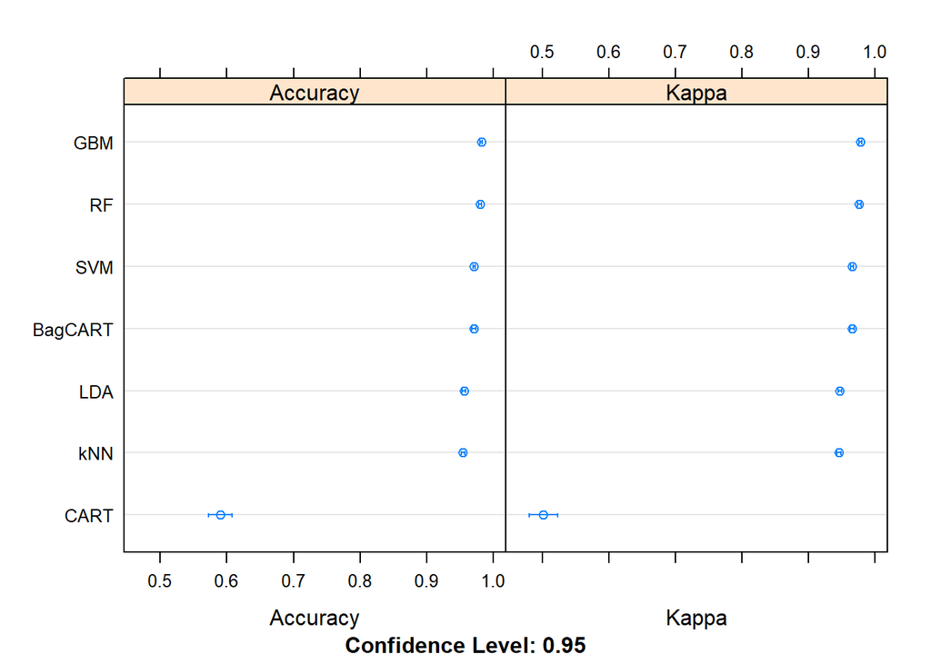

```r
dotplot(results)
```

```r
cat('The average accuracy from all models is:',
    mean(c(results$values$`LR~Accuracy`,results$values$`CART~Accuracy`,results$values$`kNN~Accuracy`,results$values$`SVM~Accuracy`,results$values$`BagCART~Accuracy`,results$values$`RF~Accuracy`,results$values$`GBM~Accuracy`)))
```

```
## The average accuracy from all models is: 0.9083602
```

## 5. Improve Accuracy or Results

After we achieve a short list of machine learning algorithms with good level of accuracy, we can leverage ways to improve the accuracy of the models.

Using the top two best-perfoming algorithms from the previous section, we will Search for a combination of parameters for each algorithm that yields the best results.

### 5.a) Algorithm Tuning

Finally, we will tune the best-performing algorithms from each group further and see whether we can get more accuracy out of them.

```r
# Tuning algorithm #1 - Random Forest
startTimeModule <- proc.time()
set.seed(seedNum)
grid <- expand.grid(mtry = c(5:9))
fit.final1 <- train(targetVar~., data=xy_train, method="rf", metric=metricTarget, tuneGrid=grid, trControl=control)
print(fit.final1)
```

```
## Random Forest
##
## 7352 samples
##  192 predictor
##    6 classes: '1', '2', '3', '4', '5', '6'
##
## No pre-processing
## Resampling: Cross-Validated (10 fold, repeated 3 times)
## Summary of sample sizes: 6619, 6617, 6616, 6618, 6615, 6617, ...
## Resampling results across tuning parameters:
##
##   mtry  Accuracy   Kappa
##   5     0.9744298  0.9692196
##   6     0.9756078  0.9706384
##   7     0.9761517  0.9712932
##   8     0.9773301  0.9727122
##   9     0.9780550  0.9735848
##
## Accuracy was used to select the optimal model using the largest value.
## The final value used for the model was mtry = 9.
```

```r
proc.time()-startTimeModule
```

```
##    user  system elapsed
## 7640.81   32.85 7677.48
```

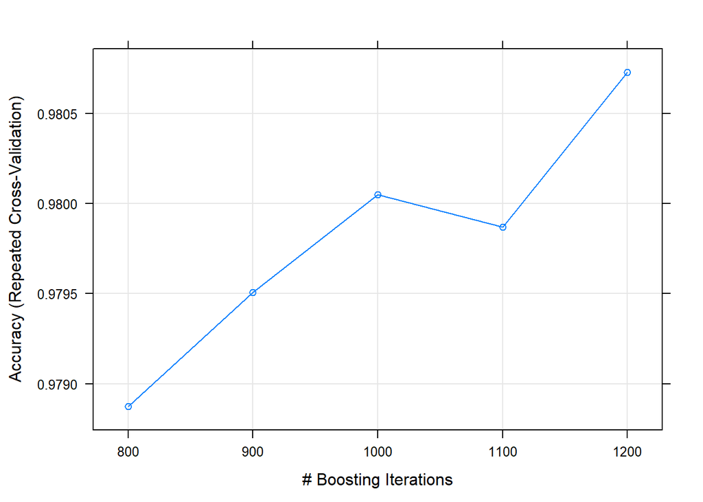

```r
# Tuning algorithm #2 - Stochastic Gradient Boosting
startTimeModule <- proc.time()
set.seed(seedNum)
grid <- expand.grid(.n.trees=c(800, 900, 1000, 1100, 1200), .shrinkage=c(0.1), .interaction.depth=c(1), .n.minobsinnode=c(10))
fit.final2 <- train(targetVar~., data=xy_train, method="gbm", metric=metricTarget, tuneGrid=grid, trControl=control, verbose=F)
plot(fit.final2)
```

```r
print(fit.final2)
```

```
## Stochastic Gradient Boosting
##
## 7352 samples
##  192 predictor
##    6 classes: '1', '2', '3', '4', '5', '6'
##
## No pre-processing
## Resampling: Cross-Validated (10 fold, repeated 3 times)
## Summary of sample sizes: 6619, 6617, 6616, 6618, 6615, 6617, ...
## Resampling results across tuning parameters:
##
##   n.trees  Accuracy   Kappa
##    800     0.9788727  0.9745690
##    900     0.9795076  0.9753333
##   1000     0.9800512  0.9759875
##   1100     0.9798699  0.9757692
##   1200     0.9807312  0.9768061
##
## Tuning parameter 'interaction.depth' was held constant at a value of
##  1
## Tuning parameter 'shrinkage' was held constant at a value of 0.1
##
## Tuning parameter 'n.minobsinnode' was held constant at a value of 10
## Accuracy was used to select the optimal model using the largest value.
## The final values used for the model were n.trees = 1200,
##  interaction.depth = 1, shrinkage = 0.1 and n.minobsinnode = 10.
```

```r
proc.time()-startTimeModule
```

```
##    user  system elapsed
## 4969.65   10.22 4982.39
```

### 5.d) Compare Algorithms After Tuning

```r
results <- resamples(list(RF=fit.final1, GBM=fit.final2))
summary(results)
```

```
##
## Call:
## summary.resamples(object = results)
##
## Models: RF, GBM
## Number of resamples: 30
##
## Accuracy
##          Min.   1st Qu.    Median      Mean   3rd Qu.      Max. NA's
## RF  0.9660326 0.9744731 0.9782016 0.9780550 0.9823129 0.9891599    0
## GBM 0.9713506 0.9769100 0.9809783 0.9807312 0.9843657 0.9891599    0
##
## Kappa
##          Min.   1st Qu.    Median      Mean   3rd Qu.      Max. NA's
## RF  0.9591127 0.9692676 0.9737611 0.9735848 0.9787098 0.9869514    0
## GBM 0.9655166 0.9722038 0.9771044 0.9768061 0.9811801 0.9869520    0
```

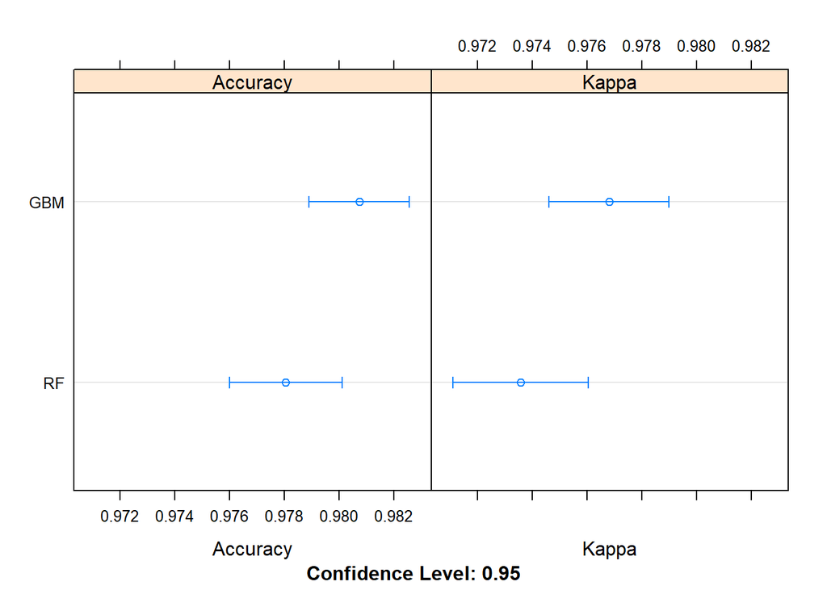

```r
dotplot(results)
```

## 6. Finalize Model and Present Results

Once we have narrow down to a model that we believe can make accurate predictions on unseen data, we are ready to finalize it. Finalizing a model may involve sub-tasks such as:

- Using an optimal model tuned to make predictions on unseen data.
- Creating a standalone model using the tuned parameters
- Saving an optimal model to file for later use.

### 6.a) Predictions on validation dataset

```r
predictions <- predict(fit.final2, newdata=xy_test)
confusionMatrix(predictions, xy_test$targetVar)
```

```
## Confusion Matrix and Statistics
##
##           Reference
## Prediction   1   2   3   4   5   6
##          1 480  40   8   0   0   0
##          2  13 421  16   2   0   0
##          3   3   7 393   0   0   0
##          4   0   1   0 441  35   0
##          5   0   2   3  48 497   0
##          6   0   0   0   0   0 537
##
## Overall Statistics
##
##                Accuracy : 0.9396
##                  95% CI : (0.9304, 0.9479)
##     No Information Rate : 0.1822
##     P-Value [Acc > NIR] : < 2.2e-16
##
##                   Kappa : 0.9274
##  Mcnemar's Test P-Value : NA
##
## Statistics by Class:
##
##                      Class: 1 Class: 2 Class: 3 Class: 4 Class: 5 Class: 6
## Sensitivity            0.9677   0.8938   0.9357   0.8982   0.9342   1.0000
## Specificity            0.9804   0.9875   0.9960   0.9853   0.9781   1.0000
## Pos Pred Value         0.9091   0.9314   0.9752   0.9245   0.9036   1.0000
## Neg Pred Value         0.9934   0.9800   0.9894   0.9798   0.9854   1.0000
## Prevalence             0.1683   0.1598   0.1425   0.1666   0.1805   0.1822
## Detection Rate         0.1629   0.1429   0.1334   0.1496   0.1686   0.1822
## Detection Prevalence   0.1792   0.1534   0.1367   0.1619   0.1866   0.1822
## Balanced Accuracy      0.9741   0.9407   0.9659   0.9418   0.9561   1.0000
```

### 6.b) Create standalone model on entire training dataset

```r
startTimeModule <- proc.time()
library(gbm)
set.seed(seedNum)
finalModel <- gbm(targetVar~., data=xy_train, n.trees=1200, verbose=F)
```

```
## Distribution not specified, assuming multinomial ...
```

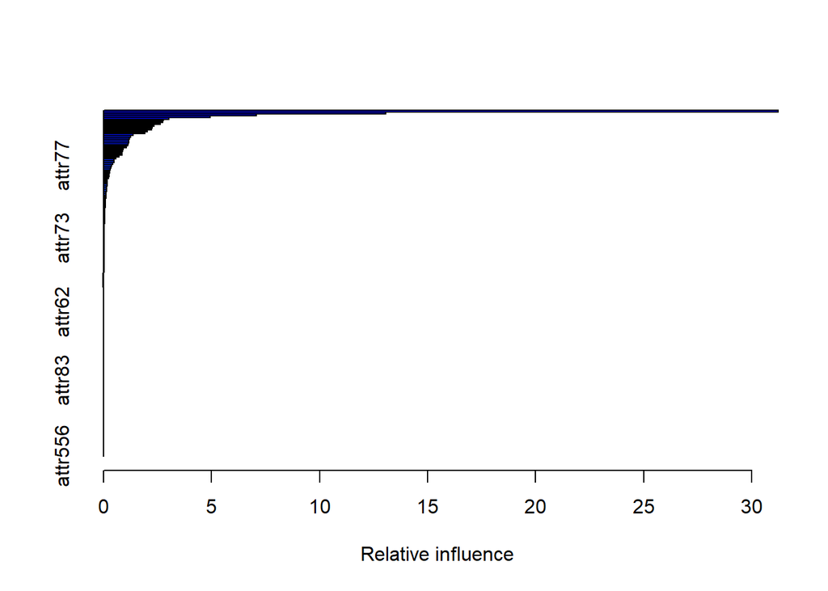

```
##             var      rel.inf
## attr559 attr559 3.121881e+01
## attr382 attr382 1.306709e+01
## attr461 attr461 7.073847e+00
## attr317 attr317 4.926838e+00
## attr298 attr298 3.018408e+00
## attr538 attr538 2.763689e+00
## attr463 attr463 2.731231e+00
## attr331 attr331 2.617503e+00
## attr451 attr451 2.330724e+00
## attr64   attr64 2.260521e+00
## attr58   attr58 2.226967e+00
## attr319 attr319 2.034416e+00
## attr304 attr304 1.901421e+00
## attr372 attr372 1.377850e+00
## attr370 attr370 1.269567e+00
## attr244 attr244 1.204974e+00
## attr38   attr38 1.184849e+00
## attr561 attr561 1.173867e+00
## attr23   attr23 1.136607e+00
## attr78   attr78 1.114788e+00
## attr462 attr462 1.072080e+00
## attr322 attr322 9.106542e-01
## attr296 attr296 8.792125e-01
## attr308 attr308 8.570294e-01
## attr490 attr490 8.539203e-01
## attr63   attr63 7.205601e-01
## attr143 attr143 5.720299e-01
## attr452 attr452 4.941372e-01
## attr121 attr121 4.854513e-01
## attr223 attr223 4.206850e-01
## attr77   attr77 3.705966e-01
## attr397 attr397 3.467412e-01
## attr187 attr187 3.189189e-01
## attr160 attr160 3.002468e-01
## attr25   attr25 2.958711e-01
## attr411 attr411 2.600931e-01
## attr450 attr450 2.507322e-01
## attr475 attr475 2.256945e-01
## attr449 attr449 1.755675e-01
```

[output cut: 138 more lines]

```
## attr338 attr338 0.000000e+00
## attr358 attr358 0.000000e+00
## attr371 attr371 0.000000e+00
## attr400 attr400 0.000000e+00
## attr402 attr402 0.000000e+00
## attr403 attr403 0.000000e+00
## attr438 attr438 0.000000e+00
## attr454 attr454 0.000000e+00
## attr458 attr458 0.000000e+00
## attr482 attr482 0.000000e+00
## attr514 attr514 0.000000e+00
## attr539 attr539 0.000000e+00
## attr546 attr546 0.000000e+00
## attr555 attr555 0.000000e+00
## attr556 attr556 0.000000e+00
```

```r
summary(finalModel)
```

```r
proc.time()-startTimeModule
```

```
##    user  system elapsed
##  179.66    0.60  180.33
```

### 6.c) Save model for later use

```r
#saveRDS(finalModel, "./finalModel_MultiClass.rds")
```

```r
proc.time()-startTimeScript
```

```
##     user   system  elapsed
## 25661.06   445.19 26128.69
```